# Data Preprocessing & Principal Components Analysis

Xuan Pham

2017-04-10

# R Packages

The packages you will need to install for the week are **splitstackshape**, **lubridate**, **dplyr**, **rgl**, and **qdapTools**.

# Learning Goal for the Week

In the past four weeks, we have examined unsupervised (cluster analysis; frequent pattern analysis) and supervised (linear regressions; decision trees) learning algorithms. In Week 5, we will take a “step back” and discuss the **bane of our existence as data scientists/analysts**: data preprocessing.

# Let’s Talk Data Quality

According to Han, Kamber, and Pei (2012), data quality consists of six elements:

- Accuracy
- Completeness
- Consistency
- Timeliness
- Believability
- Interpretability

Achieving a high level of data quality is the reason for data preprocessing.

Link to a section from [Han, Kamber, and Pei](http://mercury.webster.edu/aleshunas/Support%20Materials/Data_preprocessing.pdf)

# Three Tasks of Data Preprocessing

- Data Cleaning: fill in missing values; smoothing noisy data; identifying and removing outliers; and resolving inconsistencies.
- Data Transformation: normalization; discretization; and concept hierarchy generation.
- Data Reduction: dimensionality and numerosity reduction.

# Dataset

We are going to play with a dataset containing 5,000+ movies from IMDB. The dataset was scrapped, cleaned, and posted by [Chuan Sun](https://www.kaggle.com/deepmatrix/imdb-5000-movie-dataset) on Kaggle.

```r
imbd<-read.csv("C:/Users/PhamX/Courses/Spring_2017/BIA_6301/Module_5/data/movie_metadata.csv")
```

# A Quick Data Cleaning Exercise

```r
#str(imbd)
names(imbd)
```

```
##  [1] "color"                     "director_name"
##  [3] "num_critic_for_reviews"    "duration"
##  [5] "director_facebook_likes"   "actor_3_facebook_likes"
##  [7] "actor_2_name"              "actor_1_facebook_likes"
##  [9] "gross"                     "genres"
## [11] "actor_1_name"              "movie_title"
## [13] "num_voted_users"           "cast_total_facebook_likes"
## [15] "actor_3_name"              "facenumber_in_poster"
## [17] "plot_keywords"             "movie_imdb_link"
## [19] "num_user_for_reviews"      "language"
## [21] "country"                   "content_rating"
## [23] "budget"                    "title_year"
## [25] "actor_2_facebook_likes"    "imdb_score"
## [27] "aspect_ratio"              "movie_facebook_likes"
```

```r
summary(imbd[,c(3:6,8:9,13:14,16,19,23,25:28)])
```

```
##  num_critic_for_reviews    duration     director_facebook_likes
##  Min.   :  1.0          Min.   :  7.0   Min.   :    0.0
##  1st Qu.: 50.0          1st Qu.: 93.0   1st Qu.:    7.0
##  Median :110.0          Median :103.0   Median :   49.0
##  Mean   :140.2          Mean   :107.2   Mean   :  686.5
##  3rd Qu.:195.0          3rd Qu.:118.0   3rd Qu.:  194.5
##  Max.   :813.0          Max.   :511.0   Max.   :23000.0
##  NA's   :50             NA's   :15      NA's   :104
##  actor_3_facebook_likes actor_1_facebook_likes     gross
##  Min.   :    0.0        Min.   :     0         Min.   :      162
##  1st Qu.:  133.0        1st Qu.:   614         1st Qu.:  5340988
##  Median :  371.5        Median :   988         Median : 25517500
##  Mean   :  645.0        Mean   :  6560         Mean   : 48468408
##  3rd Qu.:  636.0        3rd Qu.: 11000         3rd Qu.: 62309438
##  Max.   :23000.0        Max.   :640000         Max.   :760505847
##  NA's   :23             NA's   :7              NA's   :884
##  num_voted_users   cast_total_facebook_likes facenumber_in_poster
##  Min.   :      5   Min.   :     0            Min.   : 0.000
##  1st Qu.:   8594   1st Qu.:  1411            1st Qu.: 0.000
##  Median :  34359   Median :  3090            Median : 1.000
##  Mean   :  83668   Mean   :  9699            Mean   : 1.371
##  3rd Qu.:  96309   3rd Qu.: 13756            3rd Qu.: 2.000
##  Max.   :1689764   Max.   :656730            Max.   :43.000
##                                              NA's   :13
##  num_user_for_reviews     budget          actor_2_facebook_likes
##  Min.   :   1.0       Min.   :2.180e+02   Min.   :     0
##  1st Qu.:  65.0       1st Qu.:6.000e+06   1st Qu.:   281
##  Median : 156.0       Median :2.000e+07   Median :   595
##  Mean   : 272.8       Mean   :3.975e+07   Mean   :  1652
##  3rd Qu.: 326.0       3rd Qu.:4.500e+07   3rd Qu.:   918
##  Max.   :5060.0       Max.   :1.222e+10   Max.   :137000
##  NA's   :21           NA's   :492         NA's   :13
##    imdb_score     aspect_ratio   movie_facebook_likes
##  Min.   :1.600   Min.   : 1.18   Min.   :     0
##  1st Qu.:5.800   1st Qu.: 1.85   1st Qu.:     0
##  Median :6.600   Median : 2.35   Median :   166
##  Mean   :6.442   Mean   : 2.22   Mean   :  7526
##  3rd Qu.:7.200   3rd Qu.: 2.35   3rd Qu.:  3000
##  Max.   :9.500   Max.   :16.00   Max.   :349000
##                  NA's   :329
```

# Made in the USA

```r
library(dplyr)
movie<-filter(imbd, country=="USA")
```

## Plot Keywords

Only the first five plot keywords are captured from the web scrapping exercise. Here’s the full IMDB page for the movie [Avatar](http://www.imdb.com/title/tt0499549/?mode=desktop&ref_=m_ft_dsk).

Let’s find out what are the most commonly used words/phrases people use to describe movies.

```r
library(splitstackshape)
library(Matrix)
library(arules)
```

```r
movie$plot_keywords<-as.character(movie$plot_keywords)

movie_2<-cSplit(movie,"plot_keywords",sep="|")
pk<-select(movie_2,c(28:32))

keywords_basket<-paste(pk$plot_keywords_1,pk$plot_keywords_2,pk$plot_keywords_3,pk$plot_keywords_4,pk$plot_keywords_5, sep="\n")

write(keywords_basket,file="C:/Users/PhamX/Courses/Spring_2017/BIA_6301/Module_5/data/keywords_basket") #write out as a text file

kb<-read.transactions("keywords_basket", format="basket", sep=",") #cannot use the read.transactions function without writing out to an output file first.
```

[output not shown]

[output cut: 109 more lines]

[output not shown]

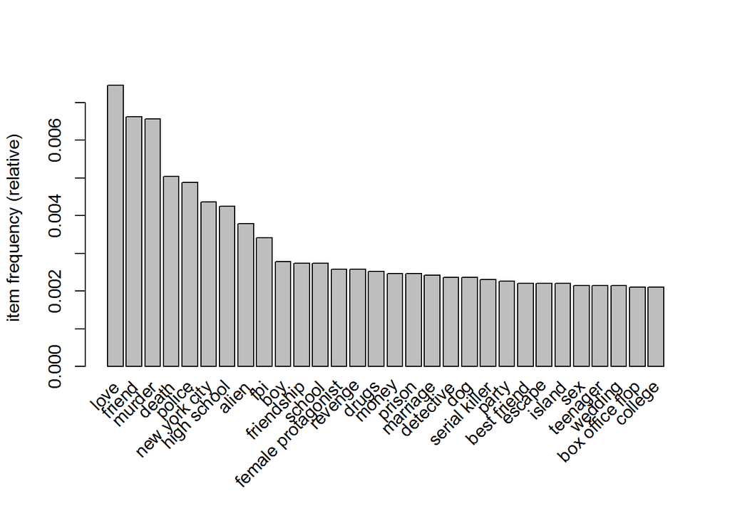

```r
freq_kwb_df <-as.data.frame(itemFrequency(kb))

itemFrequencyPlot(kb,topN=30,names=TRUE)
```

# Data Transformation

## Discretization & Concept Hierarchies

Discretization is the process of turning a numeric attribute into interval labels. The purpose of discretization is to reduce the number of unique values in the data mining process. This is particularly useful for large datasets.

Concept hierarchies replace “lower level” raw data with “higher level” categories.

```r
movie_3<-movie
names(movie_3)
```

```
##  [1] "color"                     "director_name"
##  [3] "num_critic_for_reviews"    "duration"
##  [5] "director_facebook_likes"   "actor_3_facebook_likes"
##  [7] "actor_2_name"              "actor_1_facebook_likes"
##  [9] "gross"                     "genres"
## [11] "actor_1_name"              "movie_title"
## [13] "num_voted_users"           "cast_total_facebook_likes"
## [15] "actor_3_name"              "facenumber_in_poster"
## [17] "plot_keywords"             "movie_imdb_link"
## [19] "num_user_for_reviews"      "language"
## [21] "country"                   "content_rating"
## [23] "budget"                    "title_year"
## [25] "actor_2_facebook_likes"    "imdb_score"
## [27] "aspect_ratio"              "movie_facebook_likes"
```

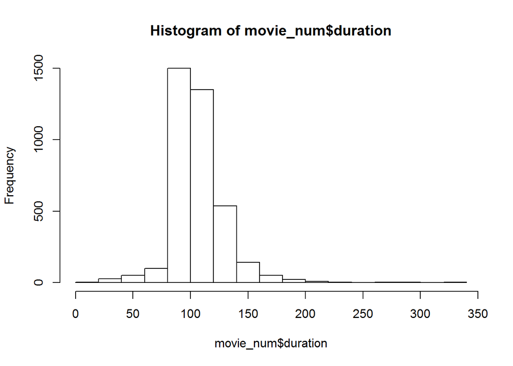

```r
movie_num<-movie_3[,c(3:6,8:9,13:14,16,19,23,25:28)] #numeric variables
hist(movie_num$duration)
```

```r
summary(movie_num$duration) #notice the 6 NA cases
```

```
##    Min. 1st Qu.  Median    Mean 3rd Qu.    Max.    NA's
##     7.0    93.0   103.0   106.4   117.0   330.0       6
```

```r
quantile(movie_num$duration,prob = seq(0, 1, length = 6),na.rm=TRUE)
```

```
##   0%  20%  40%  60%  80% 100%
##    7   91   99  108  121  330
```

### Using Percentile Rank

Let’s create a factor variable for movie length (duration). 1 = shortest; 5 = longest.

```r
movie_num<-within(movie_num,quantile<-as.integer(cut(duration,quantile(movie_num$duration,prob = seq(0, 1, length = 6), na.rm=TRUE))))

#movie_num[1921,16]<-1 #this is the movie with the shortest duration. It got left out during the process of creating quantiles.

movie_num$quantile<-as.character(movie_num$quantile)

movie_num$movie_length_perc <-factor(movie_num$quantile,levels=c(1,2,3,4,5), labels=c("Bottom Quantile", "Second Quantile","Third Quantile","Fourth Quantile","Highest Quantile"))

summary(movie_num$movie_length_perc) #notice the 7 missing NA cases.
```

```
##  Bottom Quantile  Second Quantile   Third Quantile  Fourth Quantile
##              821              751              780              716
## Highest Quantile             NA's
##              732                7
```

Let’s investigate a bit further.

```r
movie_num[is.na(movie_num$duration),]
```

```
##      num_critic_for_reviews duration director_facebook_likes
## 1273                     NA       NA                     194
## 2920                      2       NA                       3
## 3309                      5       NA                       8
## 3526                      4       NA                     364
## 3730                     NA       NA                       0
## 3764                     NA       NA                       0
##      actor_3_facebook_likes actor_1_facebook_likes   gross num_voted_users
## 1273                    816                    970      NA             219
## 2920                    723                    975      NA              38
## 3309                    394                    713 2592808             548
## 3526                    567                  22000      NA            3089
## 3730                     NA                     17      NA             172
## 3764                     15                   1000      NA             128
##      cast_total_facebook_likes facenumber_in_poster num_user_for_reviews
```

[output cut: 20 more lines]

```r
movie_num[is.na(movie_num$movie_length_perc),]
```

```
##      num_critic_for_reviews duration director_facebook_likes
## 1273                     NA       NA                     194
## 1921                     NA        7                      23
## 2920                      2       NA                       3
## 3309                      5       NA                       8
## 3526                      4       NA                     364
## 3730                     NA       NA                       0
## 3764                     NA       NA                       0
##      actor_3_facebook_likes actor_1_facebook_likes   gross num_voted_users
## 1273                    816                    970      NA             219
## 1921                     51                    344      NA             118
## 2920                    723                    975      NA              38
## 3309                    394                    713 2592808             548
## 3526                    567                  22000      NA            3089
## 3730                     NA                     17      NA             172
```

[output cut: 25 more lines]

So it seems that the shortest movie (observation 1921) was left out of the Bottom Quantile. We should go back to the previous code chunk & give the observation a quantile value = 1 (Bottom Quantile). The above code chunk needs to be run again as well.

### Using Histogram

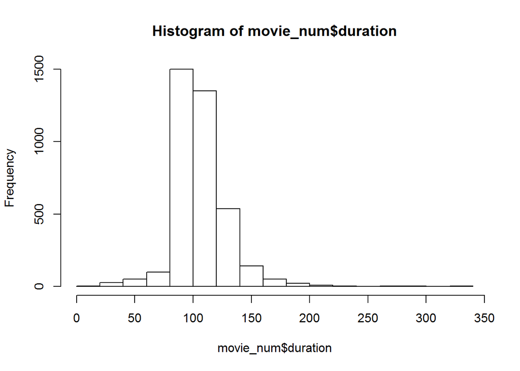

```r
hist(movie_num$duration)
```

```r
summary(movie_num$duration)
```

```
##    Min. 1st Qu.  Median    Mean 3rd Qu.    Max.    NA's
##     7.0    93.0   103.0   106.4   117.0   330.0       6
```

```r
movie_num$movie_length_hist<-
  ifelse(movie_num$duration<=100,"Short",
    ifelse (movie_num$duration<=150, "Average",
      ifelse(movie_num$duration<=511, "Long",
        ifelse(is.na(movie_num$duration), "NA"))))

table(movie_num$movie_length_hist)
```

```
##
## Average    Long   Short
##    1979     143    1679
```

```r
# does not report the NA observations but they are still there.
# 1979 "Average" + 143 "Long" + 1679 "Short" = 3801. There are 3,807 total observations. So yes, still 6 NA cases.
```

### Using Cluster Analysis

How many clusters?

Remember that cluster analysis does not like missing values. You can either recode missing values to “0” or remove them. We will recode in this exercise.

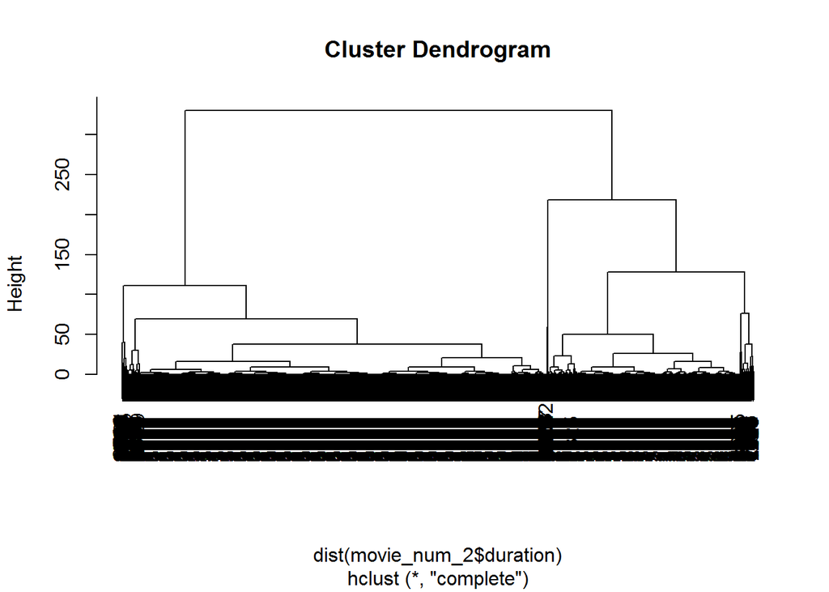

```r
movie_num_2<-movie_num #first make a copy of the data frame

movie_num_2$duration<-ifelse(is.na(movie_num$duration),0,movie_num$duration) #recode

hc_duration<-hclust(dist(movie_num_2$duration), method="complete")

plot(hc_duration)
```

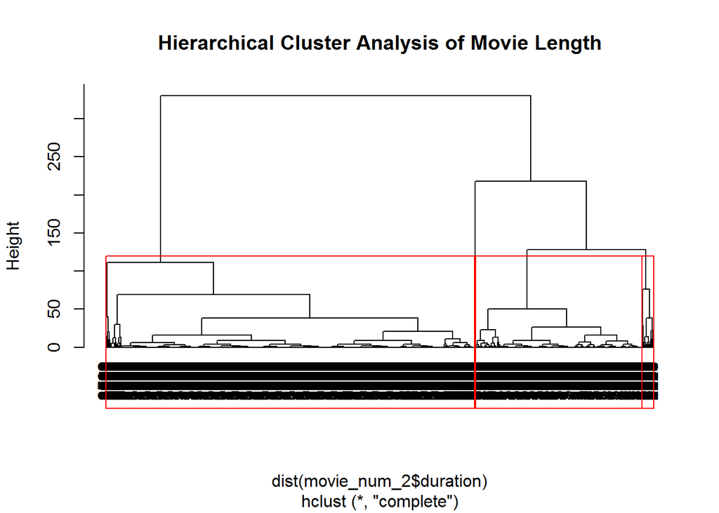

```r
dendrogram_table <- as.data.frame(hc_duration$height)


difference<-dendrogram_table$`hc_duration$height`[-1]-dendrogram_table$`hc_duration$height`[-length(dendrogram_table$`hc_duration$height`)]

difference<-as.data.frame(difference) #maybe 3 or 4 clusters?

plot(hc_duration, hang = -1, main= "Hierarchical Cluster Analysis of Movie Length")
rect.hclust(hc_duration, k=4, border="red")
```

Cleaning up the environment.

```r
movie_num_2<-NULL
```

Cleaning up the data frame.

```r
movie_num$quantile<-NULL
movie_num$movie_length_perc<-NULL
movie_num$movie_length_hist<-NULL
```

## Normalization

Normalization is when numeric attribute is transformed to be on a smaller scale. Normalization is useful for data mining techniques that uses a distance measure (knn; cluster analysis).

### Min-Max Normalization

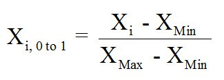

```r
normalize<- function(x,na.rm=TRUE){(x-min(x,na.rm=TRUE))/(max(x,na.rm=TRUE)-min(x.na.rm=TRUE))}
movie_num$budget_norm<-normalize(movie_num$budget)

summary(movie_num$budget_norm) #Checking the range
```

```
##    Min. 1st Qu.  Median    Mean 3rd Qu.    Max.    NA's
## 0.00000 0.02167 0.06667 0.11920 0.16670 1.00000     298
```

### Z-Score Normalization (Or Mean Zero Normalization)

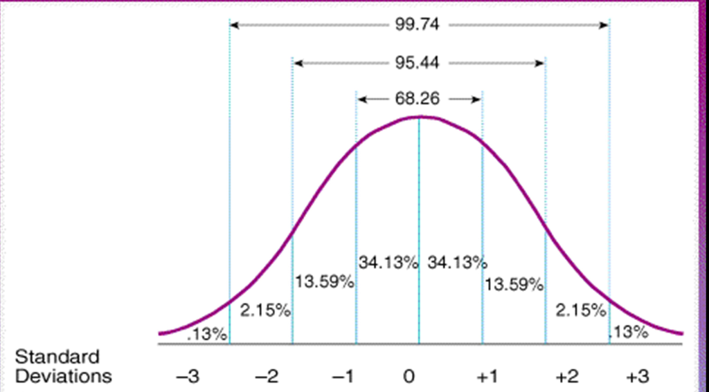

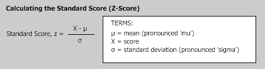

```r
movie_num$budget_z<-(movie_num$budget - mean(movie_num$budget,na.rm=TRUE))/sd(movie_num$budget,na.rm=TRUE)

summary(movie_num$budget_z)
```

```
##    Min. 1st Qu.  Median    Mean 3rd Qu.    Max.    NA's
## -0.8376 -0.6853 -0.3691  0.0000  0.3337  6.1900     298
```

```r
#Alternatively, the scale() function in base R does the same thing:
summary(scale(movie_num$budget))
```

```
##        V1
##  Min.   :-0.8376
##  1st Qu.:-0.6853
##  Median :-0.3691
##  Mean   : 0.0000
##  3rd Qu.: 0.3337
##  Max.   : 6.1900
##  NA's   :298
```

### Z Normalization with Mean Absolute Deviation (MAD)

More robust to outliers.

```r
movie_num$budget_z_mad<-(movie_num$budget - mean(movie_num$budget,na.rm=TRUE))/mad(movie_num$budget,na.rm=TRUE)
summary(movie_num$budget_z_mad)
```

```
##    Min. 1st Qu.  Median    Mean 3rd Qu.    Max.    NA's
## -1.4440 -1.1820 -0.6364  0.0000  0.5753 10.6700     298
```

### Decimal Scaling

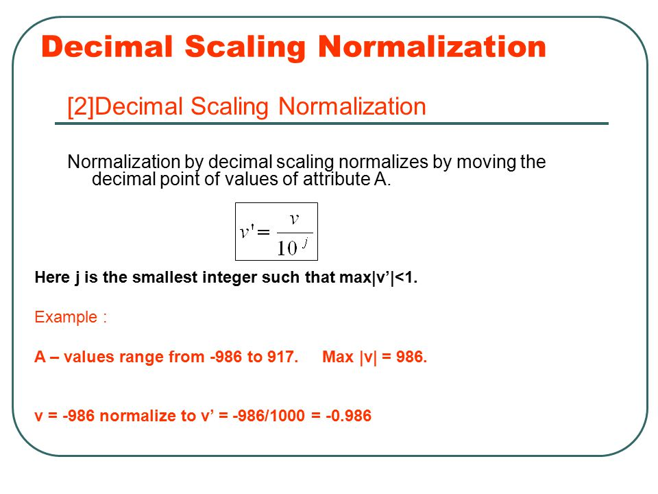

```r
max_budget<-max(movie_num$budget, na.rm=TRUE)

digits <- floor(log10( max_budget))+1

print(digits)
```

```
## [1] 9
```

```r
movie_num$budget_decimal<-(movie_num$budget)/(10^(digits))

summary(movie_num$budget_decimal)
```

```
##    Min. 1st Qu.  Median    Mean 3rd Qu.    Max.    NA's
## 0.00000 0.00650 0.02000 0.03576 0.05000 0.30000     298
```

Note: Digits code chunk above is from [here](http://stackoverflow.com/questions/6655754/finding-the-number-of-digits-of-an-integer)

Let’s clean up what we have done.

```r
movie_num$budget_norm<-NULL
movie_num$budget_z_mad<-NULL
movie_num$budget_z<-NULL
movie_num$budget_decimal<-NULL
```

# Data Reduction

The purpose of data reduction is to “obtain a reduced representation of the data set that is much smaller in volume, yet closely maintains the integrity of the original data. That is, mining on the reduced data set should produce more efficient yet produce the same (or almost the same) analytical results” (Han & Kamber 2006, p. 73).

We will discuss one way to achieve data reduction: Principal Component Analysis.

## The Curse of Dimensionality

The curse of dimensionality refers to the fact that algorithms that work in low dimensional space do not have the same performance in high dimensional space.

In a paper titled *A Few Useful Things to Know about Machine Learning*, Pedro Domingos [wrote](http://homes.cs.washington.edu/~pedrod/papers/cacm12.pdf):

After overfitting, the biggest problem in machine learning is the curse of dimensionality….Generalizing correctly becomes exponentially harder as the dimensionality (number of features) of the xamples grows, because a fixed-size training set covers a dwindling fraction of the input space.

…our intuitions, which come from a three-dimensional world, often do not apply in high-dimensional ones. In high dimensions, most of the mass of a multivariate Gaussian distribution is not near the mean, but in an increasingly distant “shell” around it; and most of the volume of a high-dimensional orange is in the skin, not in the pulp. If a constant number of examples is distributed uniformly in a a high-dimensional hypercube, beyond some dimensionality samples are closer to the face of the hypercube than to their nearest neighbor (p.4).

An example may also make things a bit clearer. Keogh and Mueen (2010) said:

For example, 100 evenly-spaced sample points suffice to sample a unit interval with no more than 0.01 distance between points; an equivalent sampling of a 10-dimensional unit hypercube with a grid with a spacing of 0.01 between adjacent points would require 10^20 sample poits: thus, in some sense, the 10D hypercube can be said to be a factor of 10^18 “larger” than the unit interval (p.257).

### What Can Go Wrong in Higher Dimensional Space?

Keogh & Mueen (2010) and Domingos (2012) noted several problems:

- Increase in dimensionality requires a large increase in observations to keep the same performance for machine learning algorithms.
- Notion of “distance” becomes meaningless. All neighbors become equidistant (=1) in high dimensional space.

## Principal Component Analysis (PCA)

PCA has many functions:

- Allows us to tackle the curse of dimensionality problem.
- Allows us to handle multicollinearity in regressions because we can use the principal components as “predictors.”
- Visualize data in a lower dimensional space.

### PCA: Intuitive Explanation

An intuitive explanation for principal components is given in [Gareth et al 2013](http://www-bcf.usc.edu/~gareth/ISL/ISLR%20Sixth%20Printing.pdf):

“Principal components are the dimensions that are closest to the n observations” (p.379)

“The first principal component loading vector has a very special property: it is the line in p-dimensional space that is closest to the n observations (using average squared Euclidean distance as a measure of closeness” (p. 379)

### PCA: Formal Definition

The formal definition of principal components are as follows:

The first principal component of a set of features X1, X2,…,Xp is the normalized linear combination of the features Z1 = a11*X1 + a2*X2 + … + ap1*Xp that has the largest variance.

a11, a21,…,ap1 are called the loadings of the principal component. These values equal to 1.

The second principal component is the linear combination of X1,…,Xp that has maximal variance out of all linear combinations that are uncorrelated with Z1 (p.376).

In this exercise, we are going to take a 15-dimensional dataset and reducing it down to something smaller.

The function prcomp does not like missing values. We will recode to 0.

```r
movie_num[is.na(movie_num)]<-0 #3801 observations

p <- prcomp(movie_num, scale=TRUE, center=TRUE)

summary(p)
```

```
## Importance of components:
##                           PC1    PC2     PC3     PC4     PC5     PC6
## Standard deviation     2.2200 1.4403 1.07779 1.02329 0.99185 0.94044
## Proportion of Variance 0.3286 0.1383 0.07744 0.06981 0.06558 0.05896
## Cumulative Proportion  0.3286 0.4669 0.54432 0.61412 0.67971 0.73867
##                            PC7     PC8    PC9    PC10    PC11    PC12
## Standard deviation     0.91222 0.87668 0.8207 0.72027 0.65248 0.56773
## Proportion of Variance 0.05548 0.05124 0.0449 0.03459 0.02838 0.02149
## Cumulative Proportion  0.79415 0.84538 0.8903 0.92487 0.95325 0.97474
##                           PC13   PC14    PC15
## Standard deviation     0.47682 0.3872 0.04024
## Proportion of Variance 0.01516 0.0100 0.00011
## Cumulative Proportion  0.98990 0.9999 1.00000
```

Looking at the loadings of the principal components.

```r
loadings<-p$rotation[,]
View(loadings)
```

Let’s see if we can visualize our principal components.

#### Bar Chart of Variance Explained by PCA

```r
p.variance.explained <-(p$sdev^2 / sum(p$sdev^2))*100
print(p.variance.explained)
```

```
##  [1] 32.85689350 13.83047471  7.74416851  6.98076160  6.55845031
##  [6]  5.89620821  5.54760456  5.12380343  4.48985788  3.45862703
## [11]  2.83819257  2.14878463  1.51570205  0.99967680  0.01079422
```

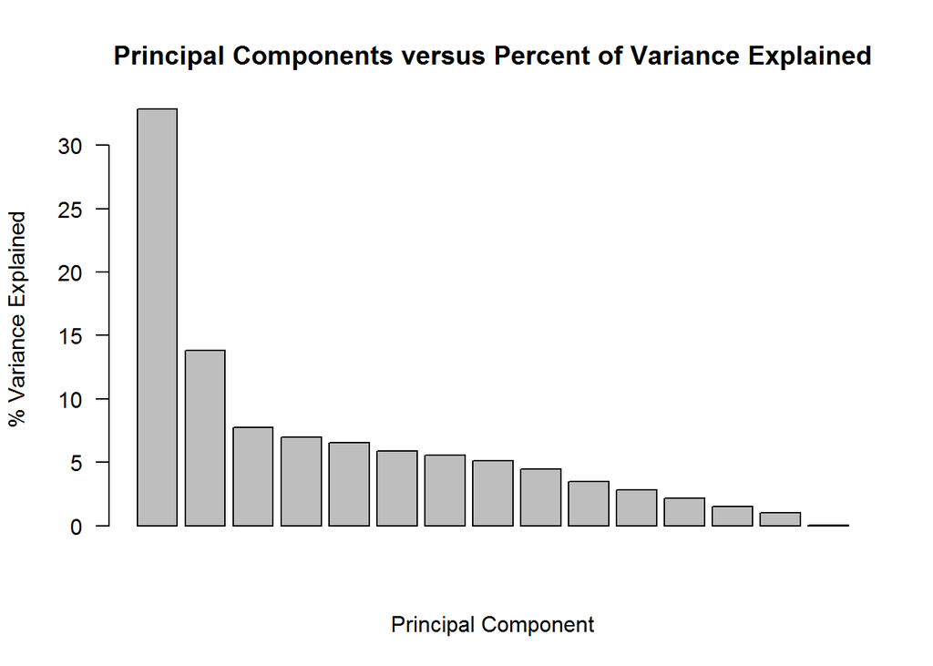

```r
# plot percentage of variance explained for each principal component
barplot(p.variance.explained, las=2, xlab="Principal Component", ylab="% Variance Explained", main="Principal Components versus Percent of Variance Explained")
```

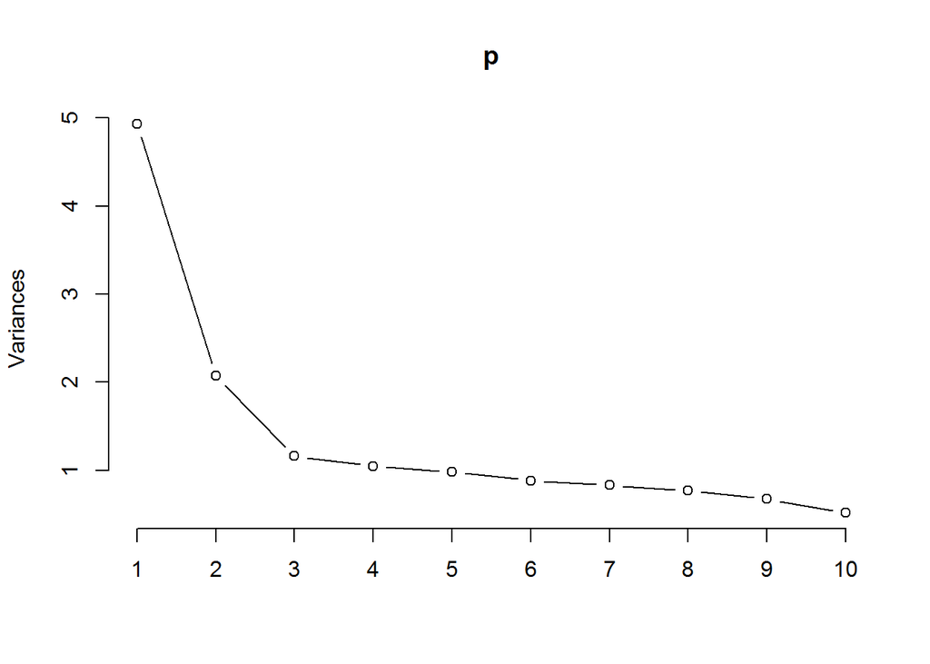

```r
screeplot(p,type="line")
```

# Shall We Cluster the Principal Components?

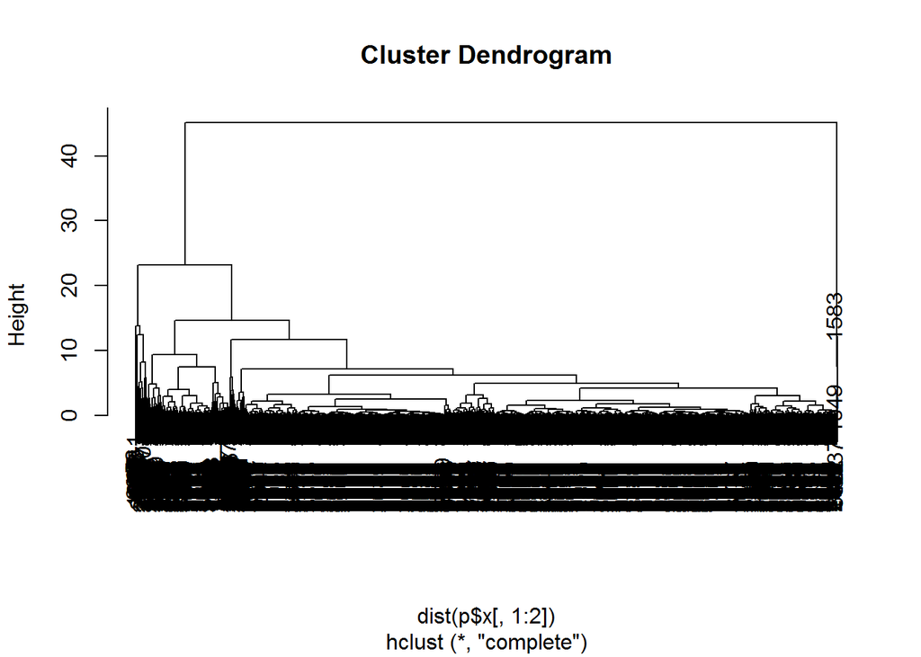

```r
hc_tree<-hclust(dist(p$x[,1:2]), method="complete") # 1:2 = based on 2 components
plot(hc_tree)
```

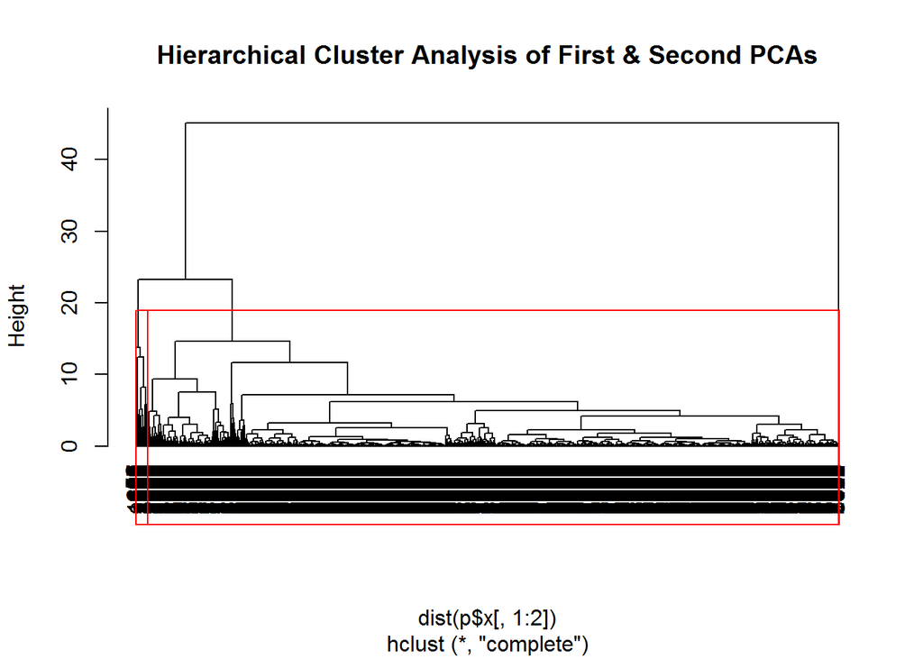

```r
groups <- cutree(hc_tree, k=4)


dendrogram_table_pca <- as.data.frame(hc_tree$height)


difference_pca<-dendrogram_table_pca$`hc_tree$height`[-1]-dendrogram_table_pca$`hc_tree`[-length(dendrogram_table_pca$`hc_tree`)]

difference_pca<-as.data.frame(difference_pca) #maybe 3 or 4 clusters?

plot(hc_tree, hang = -1, main= "Hierarchical Cluster Analysis of First & Second PCAs")
rect.hclust(hc_tree, k=4, border="red")
```

```r
movie$cluster<-groups #writing out the cluster assignment for each movie


# k = number of groups
```

# Some Interesting Characteristics about Movies

```r
table(movie$cluster)
```

```
##
##    1    2    3    4
##   65 3737    4    1
```

```r
aggregate(data = movie, duration ~ cluster, mean)
```

```
##   cluster duration
## 1       1 146.7231
## 2       2 105.7556
## 3       3  87.7500
## 4       4  98.0000
```

```r
aggregate(data = movie, budget ~ cluster, mean)
```

```
##   cluster    budget
## 1       1 155307692
## 2       2  33523736
## 3       3  14656250
## 4       4  26000000
```

```r
aggregate(data = movie, gross ~ cluster, mean)
```

```
##   cluster     gross
## 1       1 292924161
## 2       2  50340538
## 3       3  33281553
## 4       4  84136909
```

```r
aggregate(data = movie, imdb_score ~ cluster, mean)
```

```
##   cluster imdb_score
## 1       1   7.615385
## 2       2   6.345946
## 3       3   5.950000
## 4       4   7.200000
```

Cluster 1: **The Blockbusters (65 movies)**

Long movies (average 147 minutes); big budget (average $155 million); box office hits (average $290 million); highest IMDB score (average 7.6).

Cluster 2: **Weekend Standard Fare (3,737 movies)**

Average length movies (average 106 minutes); mid-sized budget (average $33 million); weekend opening leaders (average $50 million); average IMDB score (average 6.3)

Short movies (average 88 minutes); small budget (average $15 million); box office flops (average $33 million); terrible IMDB score (average 6.0)

Cluster 4: **The Unicorn (1 movie)**

Average length movie (average 98 minutes); small budget (averge $26 million); box office hit ($84 million); high IMDB score (7.2)

Let’s see what these movies are.

```r
Cluster_1<-subset(movie,cluster==1)
Cluster_2<-subset(movie,cluster==2)
Cluster_3<-subset(movie,cluster==3)
Cluster_4<-subset(movie,cluster==4)
```

A practical question: Do we need to keep all 4 clusters? Which cluster(s) would you remove & why?

# Another PCA Application

We are going to replicate an exercise conducted by Hakkio and Willis (2013) of the Federal Reserve Bank of Kansas City. Hakkio and Willis created two measures of labor market conditions from 23 labor market variables. One measure tracks the level of activity of labor market conditions. The second measure tracks the rate of change.

Here are some useful links:

[LMCI](https://www.kansascityfed.org/research/indicatorsdata/lmci)

[Macro Bulletin](https://www.kansascityfed.org/publicat/research/macrobulletins/mb13Hakkio-Willis0718.pdf)

In our exercise, we can only get access to 15 variables since the remaining ones are proprietary information. In any case, our goal is to take a dataset in 15 dimensions and reducing it down to 2 dimensions.

First, we need to do some data wrangling.

```r
library(lubridate)
LMCI_large<-read.csv("C:/Users/PhamX/Courses/Spring_2017/BIA_6301/Module_5/data/LMCI_month.csv")
LMCI_small<-read.csv("C:/Users/PhamX/Courses/Spring_2017/BIA_6301/Module_5/data/LMCI_week.csv")

#let's handle the LMCI_small dataset first.
LMCI_small$date<-ymd(as.character(LMCI_small$DATE)) #we have to convert the DATE into "Date" format.
LMCI_small$year<-year(LMCI_small$date)
LMCI_small$month<-month(LMCI_small$date)
LMCI_small.2<-as.data.frame(aggregate(ICSA~year+month, LMCI_small, mean))
LMCI_small.3<-LMCI_small.2[order(LMCI_small.2$year,LMCI_small.2$month),]#sort by year and month

#and now we deal with the larger LMCI_month dataset.
LMCI_large$date<-ymd(as.character(LMCI_large$DATE))
LMCI_large$year<-year(LMCI_large$date)
LMCI_large$month<-month(LMCI_large$date)
LMCI_large.2<-LMCI_large[order(LMCI_large$year,LMCI_large$month),]
LMCI_large.3<-LMCI_large.2[,c(-1,-16)]

#merging will cause us to lose one observation for ISCA since there is a value for the month of April 2016 but there are no values for this month for the other 14 variables.
LMCI_combined<-merge(LMCI_small.3,LMCI_large.3, by=c("year", "month"))
LMCI_combined<-LMCI_combined[,c(-1,-2)]
```

And now onto the PCA.

```r
LMCI_combined_zscore<-data.frame(scale(LMCI_combined))

#Checking to see if z-score normalization works. We expect mean=0 and sd=1.
sapply(LMCI_combined_zscore, mean)
```

```
##          ICSA        AHETPI          AWHI       CIVPART       EMRATIO
## -3.576004e-18 -2.031571e-16  4.899051e-16 -1.064059e-15 -5.643324e-16
##   LNS12032194   LNS13023622   LNS13023706   LNS13025703   LNS17100000
##  5.032859e-17 -1.551042e-17  3.065913e-16 -1.117475e-16  8.720540e-16
##        NAPMEI     TEMPHELPS        U6RATE        UNRATE        USPRIV
## -3.087808e-16  8.882261e-18            NA  1.546173e-16 -4.003761e-16
```

```r
sapply(LMCI_combined_zscore, sd)
```

```
##        ICSA      AHETPI        AWHI     CIVPART     EMRATIO LNS12032194
##           1           1           1           1           1           1
## LNS13023622 LNS13023706 LNS13025703 LNS17100000      NAPMEI   TEMPHELPS
##           1           1           1           1           1           1
##      U6RATE      UNRATE      USPRIV
##          NA           1           1
```

```r
LMCI_pca<-prcomp(na.omit(LMCI_combined_zscore), center=TRUE, scale=TRUE)
summary(LMCI_pca)
```

```
## Importance of components:
##                           PC1    PC2     PC3     PC4    PC5     PC6    PC7
## Standard deviation     2.9327 2.0245 1.18825 0.65939 0.4313 0.33165 0.2354
## Proportion of Variance 0.5734 0.2732 0.09413 0.02899 0.0124 0.00733 0.0037
## Cumulative Proportion  0.5734 0.8466 0.94075 0.96973 0.9821 0.98947 0.9932
##                            PC8     PC9    PC10    PC11    PC12    PC13
## Standard deviation     0.22224 0.15869 0.10991 0.09545 0.06831 0.03871
## Proportion of Variance 0.00329 0.00168 0.00081 0.00061 0.00031 0.00010
## Cumulative Proportion  0.99645 0.99813 0.99894 0.99954 0.99986 0.99996
##                           PC14    PC15
## Standard deviation     0.02009 0.01626
## Proportion of Variance 0.00003 0.00002
## Cumulative Proportion  0.99998 1.00000
```

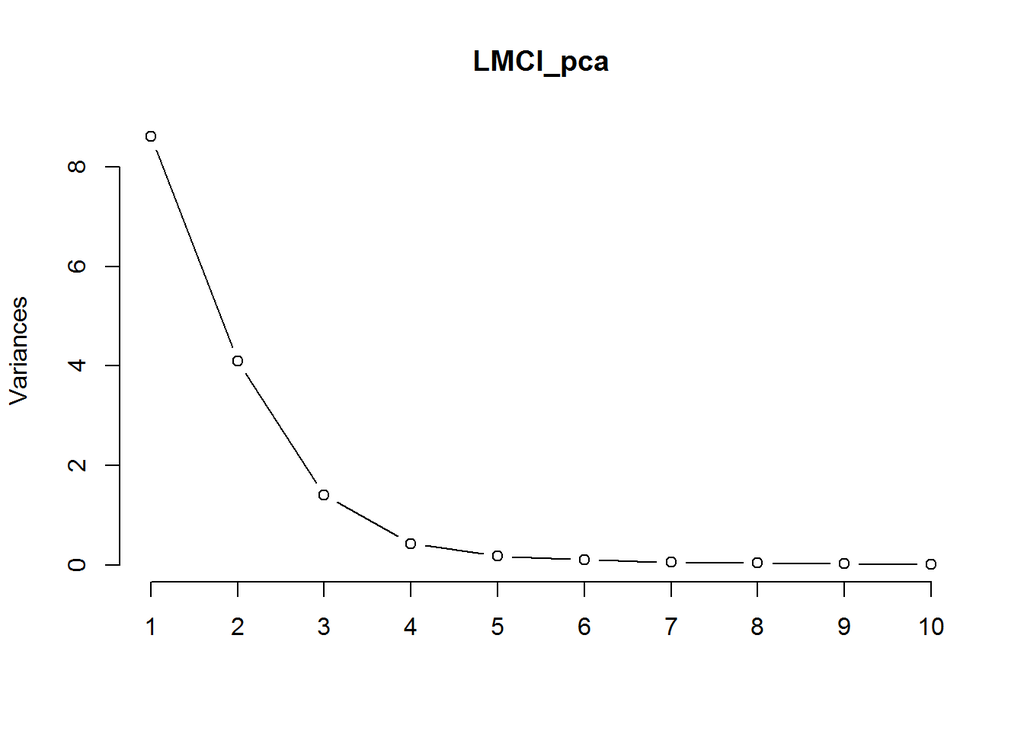

```r
screeplot(LMCI_pca, type="lines") #note the first two PC account for 84% of the variance in the data.
```

```r
LMCI_pca$rotation[,1]
```

```
##        ICSA      AHETPI        AWHI     CIVPART     EMRATIO LNS12032194
##  0.18337405  0.27090091  0.07926411 -0.26588937 -0.32885299  0.33438954
## LNS13023622 LNS13023706 LNS13025703 LNS17100000      NAPMEI   TEMPHELPS
##  0.28794758 -0.31985989  0.32575518  0.28289429  0.09491689  0.01514861
##      U6RATE      UNRATE      USPRIV
##  0.32618120  0.31500440  0.09907381
```

```r
#PC1 = 0.183*ICSA + 0.271*AHETPI + ...

LMCI_pca$rotation[,2]
```

```
##        ICSA      AHETPI        AWHI     CIVPART     EMRATIO LNS12032194
##  0.29517668 -0.28656349 -0.45623486  0.24760501  0.07101677  0.01186852
## LNS13023622 LNS13023706 LNS13025703 LNS17100000      NAPMEI   TEMPHELPS
##  0.13508390 -0.10895801 -0.02785064  0.17416145 -0.15488718 -0.48445786
##      U6RATE      UNRATE      USPRIV
##  0.12618925  0.17454919 -0.43566200
```

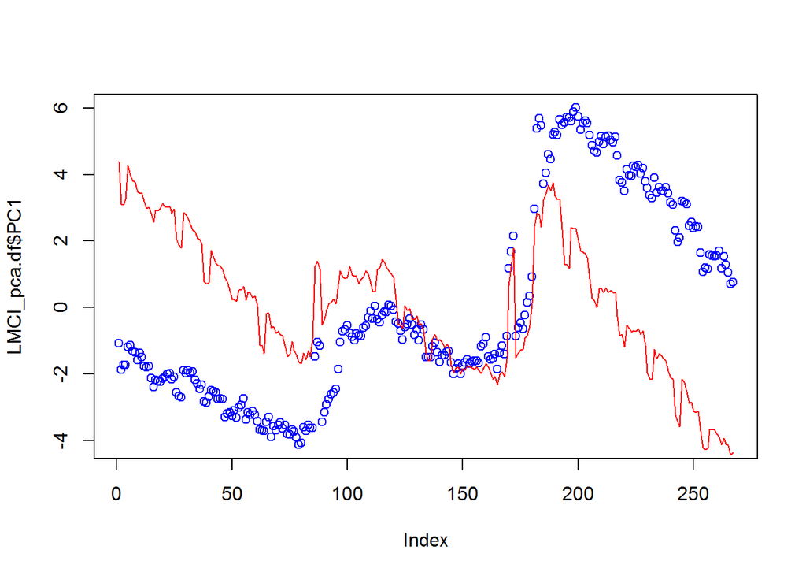

```r
#PC2 = 0.30*ICSA - 0.287*AHETPI + ...

LMCI_pca.df<-data.frame(LMCI_pca$x[,1:2])

plot(LMCI_pca.df$PC1, col="blue") #level of activity index?
lines(LMCI_pca.df$PC2, col="red") #rate of change index?
```

In the above PCA example, we omitted the first 24 observations due to the NA’s for the variable U6RATE. Omission means we have to deal with less data points, and, thus, less variation. What other data preprocessing techniques we could have used to handle the missing values?

# Because We Love the Bakery Dataset

Now think about taking a dataset that has 51 dimensions and reducing it down to two dimensions.

```r
library(cluster)
library(fpc)

bakery <- read.csv("C:/Users/PhamX/Courses/Spring_2017/BIA_6301/Module_3/assignment/bakery-binary.csv")
str(bakery)
```

```
## 'data.frame':    1000 obs. of  51 variables:
##  $ Chocolate.Cake     : int  0 0 1 0 0 0 0 0 1 1 ...
##  $ Lemon.Cake         : int  0 0 0 0 0 0 0 0 0 0 ...
##  $ Casino.Cake        : int  0 0 0 1 1 0 0 0 0 1 ...
##  $ Opera.Cake         : int  0 1 0 0 0 0 1 1 0 0 ...
##  $ Strawberry.Cake    : int  0 0 1 0 0 0 0 0 0 0 ...
##  $ Truffle.Cake       : int  0 0 0 0 0 0 0 0 0 0 ...
##  $ Chocolate.Eclair   : int  0 0 0 1 0 0 0 1 0 0 ...
##  $ Coffee.Eclair      : int  0 0 0 0 0 0 0 0 0 0 ...
##  $ Vanilla.Eclair     : int  0 0 0 0 0 0 0 0 0 0 ...
##  $ Napoleon.Cake      : int  0 0 1 0 0 1 0 0 0 0 ...
##  $ Almond.Tart        : int  0 0 0 0 1 0 0 0 0 0 ...
##  $ Apple.Pie          : int  0 0 0 0 0 0 0 0 0 0 ...
##  $ Apple.Tart         : int  0 0 0 0 0 0 0 0 0 0 ...
##  $ Apricot.Tart       : int  0 0 0 0 0 0 0 1 0 0 ...
```

[output cut: 37 more lines]

```r
#View(bakery)

#pca using raw data
set.seed(12345)
bakery_pca<-prcomp(bakery)
summary(bakery_pca)
```

```
## Importance of components:
##                            PC1     PC2    PC3     PC4     PC5     PC6
## Standard deviation     0.47420 0.43099 0.4138 0.40257 0.39356 0.38838
## Proportion of Variance 0.06448 0.05326 0.0491 0.04647 0.04441 0.04325
## Cumulative Proportion  0.06448 0.11774 0.1668 0.21331 0.25772 0.30098
##                            PC7    PC8     PC9    PC10    PC11   PC12
## Standard deviation     0.37415 0.3669 0.35609 0.34475 0.33271 0.3304
## Proportion of Variance 0.04014 0.0386 0.03636 0.03408 0.03174 0.0313
## Cumulative Proportion  0.34112 0.3797 0.41608 0.45016 0.48190 0.5132
##                           PC13    PC14    PC15    PC16    PC17    PC18
## Standard deviation     0.31357 0.31076 0.24869 0.24380 0.24180 0.24090
## Proportion of Variance 0.02819 0.02769 0.01773 0.01704 0.01677 0.01664
## Cumulative Proportion  0.54139 0.56908 0.58682 0.60386 0.62063 0.63727
##                           PC19   PC20    PC21    PC22    PC23    PC24
## Standard deviation     0.23443 0.2310 0.22539 0.22112 0.22027 0.21703
## Proportion of Variance 0.01576 0.0153 0.01457 0.01402 0.01391 0.01351
## Cumulative Proportion  0.65302 0.6683 0.68289 0.69691 0.71083 0.72433
##                           PC25   PC26    PC27    PC28    PC29    PC30
## Standard deviation     0.21555 0.2145 0.21145 0.20861 0.20669 0.20520
## Proportion of Variance 0.01332 0.0132 0.01282 0.01248 0.01225 0.01207
## Cumulative Proportion  0.73766 0.7509 0.76367 0.77615 0.78840 0.80047
##                           PC31    PC32    PC33    PC34    PC35    PC36
## Standard deviation     0.20246 0.20055 0.19835 0.19736 0.19552 0.19402
## Proportion of Variance 0.01175 0.01153 0.01128 0.01117 0.01096 0.01079
## Cumulative Proportion  0.81223 0.82376 0.83504 0.84621 0.85717 0.86796
##                           PC37    PC38   PC39    PC40   PC41    PC42
## Standard deviation     0.19207 0.18889 0.1876 0.18631 0.1820 0.18001
## Proportion of Variance 0.01058 0.01023 0.0101 0.00995 0.0095 0.00929
## Cumulative Proportion  0.87854 0.88877 0.8989 0.90882 0.9183 0.92761
##                           PC43    PC44    PC45    PC46    PC47    PC48
## Standard deviation     0.17821 0.17741 0.17396 0.16974 0.16956 0.16786
## Proportion of Variance 0.00911 0.00903 0.00868 0.00826 0.00824 0.00808
## Cumulative Proportion  0.93672 0.94574 0.95442 0.96268 0.97093 0.97900
##                           PC49    PC50    PC51
## Standard deviation     0.16422 0.15728 0.14668
## Proportion of Variance 0.00773 0.00709 0.00617
## Cumulative Proportion  0.98674 0.99383 1.00000
```

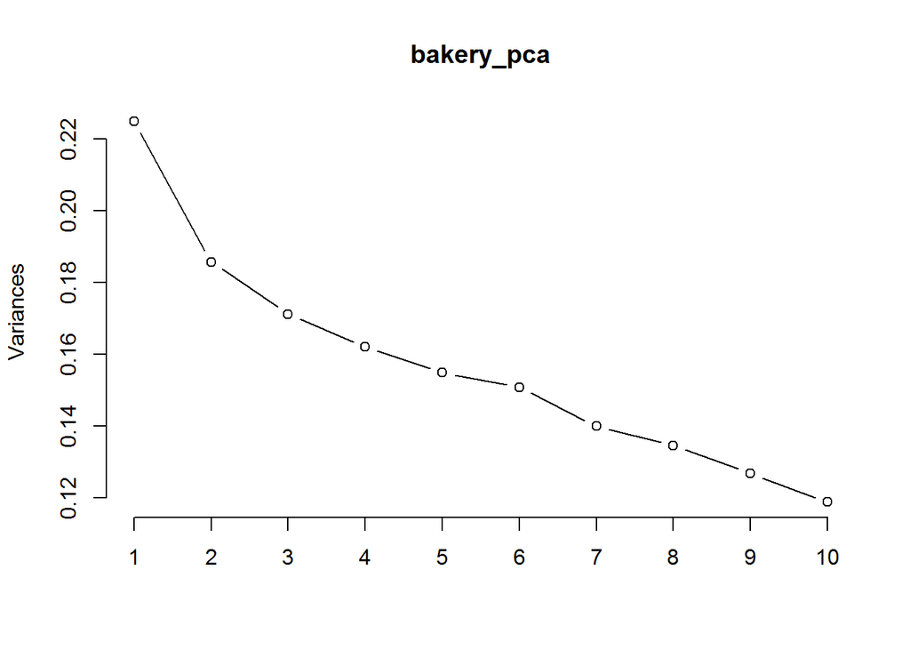

```r
screeplot(bakery_pca, type="lines")
```

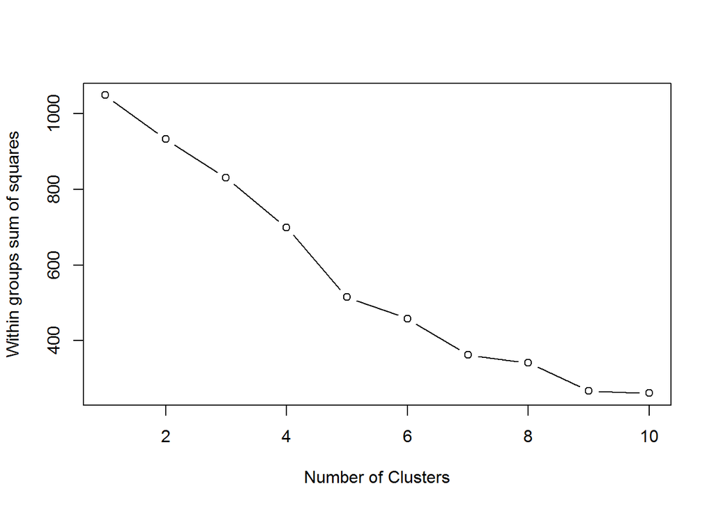

```r
bakery_pca.df<-data.frame(bakery_pca$x[,1:6]) #first 6 PCs


#Using the elbow method. Maybe 5 groups?
set.seed(12345)
wss <- (nrow(bakery_pca.df)-1)*sum(apply(bakery_pca.df,2,var))
for (i in 2:10) wss[i] <- sum(kmeans(bakery_pca.df,
                                     centers=i)$withinss)
plot(1:10, wss, type="b", xlab="Number of Clusters",
     ylab="Within groups sum of squares")
```

Clustering the first six PCAs to come up with cluster assignments.

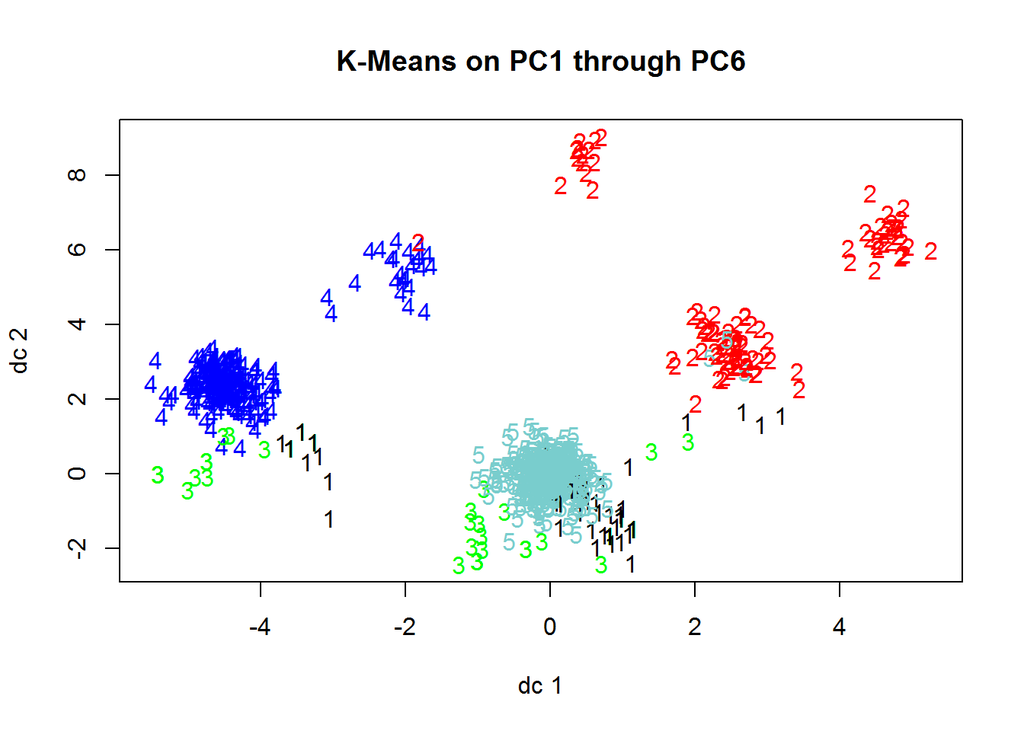

```r
set.seed(12345)
bakery_cluster_pca<-kmeans(bakery_pca.df, center=5)
plotcluster(bakery, bakery_cluster_pca$cluster, main="K-Means on PC1 through PC6")
```

Now we take the cluster assignments and attach to the bakery dataset.

```r
bakery$cluster<-bakery_cluster_pca$cluster

table(bakery$cluster)
```

```
##
##   1   2   3   4   5
##  88 120  50 263 479
```

```r
Cluster_1<-subset(bakery,cluster==1)

library(qdapTools)
Cluster_1_purchases<-as.data.frame(addmargins(as.matrix(mtabulate(Cluster_1[-52])),2))
```

The code chunk above can be repeated to examine the other clusters.